# The Logic Trap

Why the Traditional Story Breaks Itself

Author

Tehran Davis

## Today’s Goal

Tuesday: We sketched the **Traditional Story** of perception.

Today: We **stress-test** that story and provide context for your assigned readings

## The 8 Core Assumptions

**The “Standard Story” rests on these pillars:**

1. **Realism:** The world actually exists.
2. **Empiricism:** We start with no knowledge (Blank Slate).
3. **Senses Inform:** Senses are our only bridge to the world.
4. **Local Causality:** To cause perception, something must *touch* the sensor.
5. **Mediated Contact:** We contact a *copy* (image), not the world.
6. **Poverty of Stimulus:** The copy is bad/ambiguous.
7. **Unconscious Inference:** The brain *fixes* the copy using rules.
8. **Representation:** We experience the *fix*, not the raw input.

# Part 1: Local Causality & The Outness Problem

## What You Learned in Intro S&P

**Transduction:** Light energy → Neural signals

The process:

1. Light reflects off object
2. Light enters eye, hits photoreceptors
3. Photoreceptors convert light to electrical signals
4. Signals travel via optic nerve to brain

The critical point: stimulation happens **at the receptor**.

The light *touches* your retina. The sound wave *touches* your cochlea.

## The Hidden Assumption

**Local Causality:** For A to cause B, A must be in direct contact with B.

This seems obvious. Billiard balls work this way.

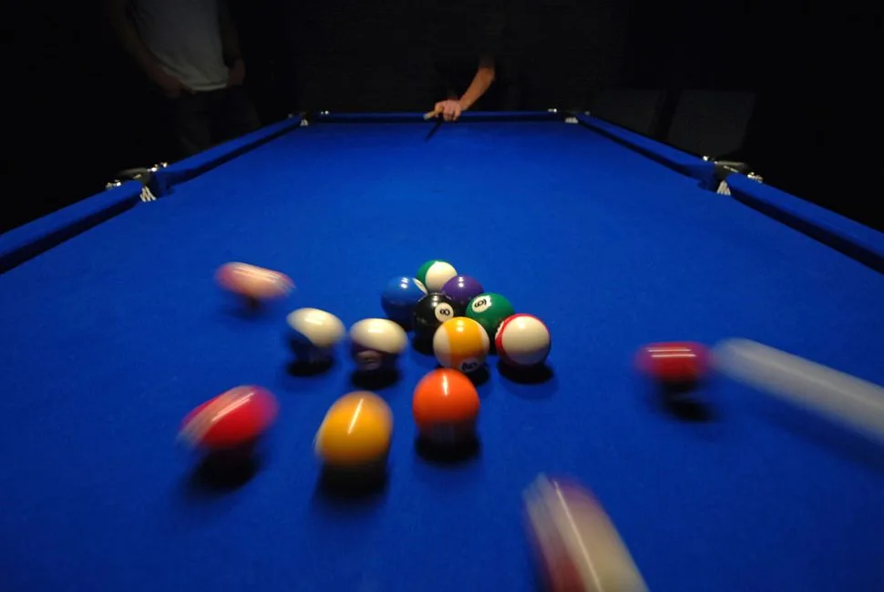

## The Hidden Assumption

**But consider:** You’re skiing downhill and a tree is 100 feet away. It never touches you. Yet it *causes* your behavior - you steer away from it.

[video not shown]

## The Traditional Solution

Q: How can a distant object cause your behavior if causality requires contact?

A: We insert a **mediator**:

The tree doesn’t touch you. But light does.

Light carries a **copy** of the tree to your eye.

Problem solved, right?

## The Outness Problem

**The Trap:** All stimulation is *local* - literally on your eyeball, in your ear, on your skin.

But you don’t experience light *on your retina*.

You experience a tree *over there*.

The Central Executive only receives signals from receptors **inside the body**.

It has never touched the tree. It has no direct access to “out there.”

**How does it know to project the experience outward?**

## The Outness Problem (cont.)

Think about what the brain actually receives:

- Photoreceptors firing (location: back of eyeball)
- Frequency of firing
- Which receptors fired

That’s it. Just neural signals from **in here**.

Where in that data does it say “50 feet away”?

What **rule** converts “signal from inside my head” to “experience out in the world”?

## Activity: The Cane Demo

You feel the object **at the tip of the cane**.

You feel the **distance** of the object.

But your nerves are **in your hand**.

The stimulation is local (pressure on palm). The experience is distal (at the object).

How did your brain “project” the feeling to the end of the cane?

# Part 2: The Poverty of the Stimulus

## What You Learned in Intro S&P

**Depth Cues** - You probably memorized a list:

- Binocular disparity
- Convergence
- Texture gradient
- Linear perspective
- Relative size
- Motion parallax
- …and more

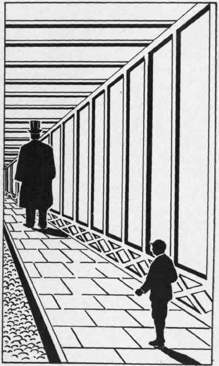

**Question:** Why do we need so many cues for depth?

## The Hidden Assumption

**The Poverty of the Stimulus:** The retinal image is fundamentally inadequate.

- 3D world → 2D image (depth lost)
- Upright world → Inverted image
- Stable world → Constantly shifting image

We need 15 depth cues because the input **doesn’t contain depth**.

The information is “impoverished” - too poor to specify the world.

The brain must **add back** what the image lacks.

## The Geometry of Ambiguity

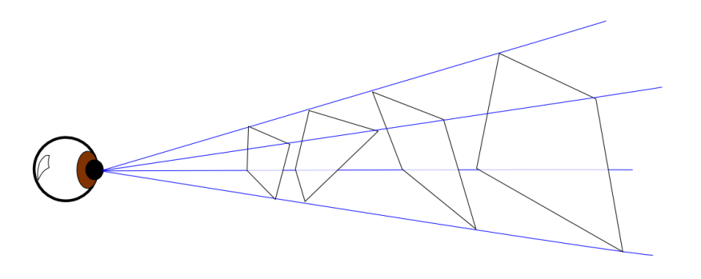

An infinite number of objects at different sizes and distances produce the **same** retinal image.

The image is geometrically **ambiguous**.

## The Classic Problem: The Walking “Professor”

Watch me walk away from you.

When I am 10 feet away, I cast a large image on your retina.

When I am 20 feet away, that image is **cut in half**.

Did I shrink? No.

So what **rule** tells your brain “ignore the shrinking image, the professor is constant”?

**Size Constancy:** The brain “corrects” for distance. *But* how does it know distance in order to correct for it?

## The Beuchet Chair Illusion

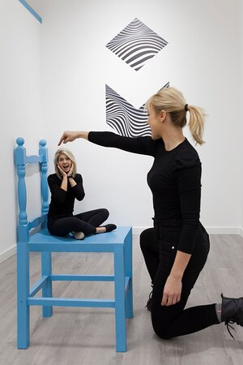

Two people appear drastically different in size.

All your depth cues are working “correctly.”

They just happen to be **wrong**.

One step to the side and the illusion collapses. What does that tell you?

# Part 3: Unconscious Inference

## The Logical Necessity

**Why *must* the brain infer?**

1. **Poverty of Stimulus:** The sensory data is ambiguous/bad.
2. **Indirect contact:** You have no direct access to the world.

If the data is broken and you have no direct access to the world… **You have to guess.** You have to use rules to “fix” the input.

The logic is sound. **IF** the data is impoverished, then inference is necessary.

**But here is a question we rarely ask:**

How do we *know* the data is impoverished?

## What You Learned in Intro / S&P

**Unconscious Inference (Helmholtz):**

The brain uses **cues** + **rules** + **prior experience** to compute what’s probably out there given its understanding of the world.

Cue + Rule + Likelihood → Perception

Example: “Lines converging + rule about perspective + most things aren’t shrinking = that object is receding”

This happens unconsciously, automatically, effortlessly.

## The Trap: Where Do Rules Come From?

**The Loan of Intelligence Problem:**

To interpret the first image, you need rules.

To learn rules, you need interpreted images.

Where does the first rule come from?

The Central Executive starts with the **tabula rasa** (blank slate).

Yet it needs prior knowledge to interpret *any* input.

This is a logical impossibility.

## The Riddle of Abduction

**Abduction** = “Inference to the **Best** Explanation.”

Your brain receives ambiguous input and must guess the single *best* cause.

**The Dilemma:** 1. There are infinite possible causes (hypotheses).

2. To be **sure** you picked the *best* one, you’d need to check them all against everything you know (Holism).
3. But you have to perceive in **milliseconds** (Encapsulation).

**The Trap:** If you check everything, you’ll never decide in time. If you use shortcuts (rules), how do you know you didn’t miss the right answer?

## The Literal Rule Problem

Every rule requires a rule to apply it.

Every interpretation requires an interpretation.

The Instructions Need to be Exact

[video not shown]

**The Point:** Literal rules fail because the world is messy. You need context. But you need a rule to interpret the context…

# Part 4: The Processing Time Problem

## Rationality is Computational

If perception is **Unconscious Inference**, then it is a **computational process**.

You are taking data, applying rules, and calculating the “best guess”.

**Calculation takes time.**

Therefore, if perception is rational, **it cannot be instantaneous.**

## What You Learned in Intro / S&P

**Reaction Time:**

- Simple RT: ~150-200ms
- Choice RT: ~250-350ms

**Neural Conduction:**

- Signals travel at ~100 m/s (not instant)
- Processing adds delay at every synapse

The nervous system is **not instantaneous**.

## The Hidden Assumption

If perception requires **processing** (inference, computation, construction)…

Then perception takes **time**.

You are always perceiving the **past**.

By the time signals reach your brain, get processed, and generate a response…

The world has already moved on.

## The Math Problem

**A fastball:**

- Speed: ~90 mph
- Distance: 60 feet
- Travel time: ~400ms

**Your visual processing:**

- Retina to cortex: ~50ms
- “Interpretation”: ~50-100ms
- Motor planning: ~50ms
- Motor execution: ~100ms

**Total:** 250-300ms just to *start* swinging

[video not shown]

The ball is 2/3 of the way there before you begin to move.

## The Mars Rover Problem

You’re controlling your body like NASA controls a Mars rover:

- See ball → Process → Decide → Swing
- Each step takes time
- You’re always **behind**

Yet somehow, batters hit 90mph fastballs.

Outfielders catch fly balls.

You catch your keys when someone tosses them.

**How?**

## Activity: The Ball Toss

I’m going to toss this [crumpled paper ball] to one of you.

Catch it.

Congratulations. You just did something **impossible** according to the traditional model.

If you had to:

1. See the ball
2. Compute its trajectory
3. Predict where it will be
4. Plan your arm movement
5. Execute the catch

…you’d be too late. Always.

Yet you caught it. How?

# The Summary

## The Chain of Assumptions

1. Local Causality (must touch to cause)
2. Need a mediator (the copy/retinal image)
3. Copy is bad (poverty of stimulus)
4. Must fix the copy (unconscious inference)

## The Traps We Found

| Problem | What Breaks |
| --- | --- |
| Outness Problem | How does “in here” become “out there”? |
| Poverty of Stimulus | Infinite objects → same image |
| Infinite Regress | Rules need rules need rules… |
| Processing Time | Always behind, can’t catch a ball |

**All trace back to the assumption that perception is indirect.**

## The Escape Hatch

What if we **reject** local causality?

- What if the tree *can* affect Fred without a mediator?
- What if there is no “copy”?
- What if the input **isn’t** bad?
- What if perception **doesn’t** require inference?

This is exactly what **James Gibson** proposed.

This is exactly what you’ll read this weekend.

## Your Reading

**Blau & Wagman, Chapters 1-2**

*Introduction to Ecological Psychology: A Lawful Approach to Perceiving, Acting, and Cognizing*

As you read, look for:

1. How do they trace all these problems to their **root cause**?
2. What **alternative** do they propose?
3. Does it actually solve the traps we found today?

## For Tuesday

**1. Come with Questions** From the reading or today’s lecture.

**2. The “Real World” Challenge**

Find one example of a daily task (walking, driving, catching) where the “Traditional Story” (Local Causality, Processing Time, etc.) seems to fail.

*Be ready to share how the “Standard Story” can’t explain what we actually do.*